# Digital Tissue Deconvolution an exemplary analysis

## Assess the standard deconvolution model

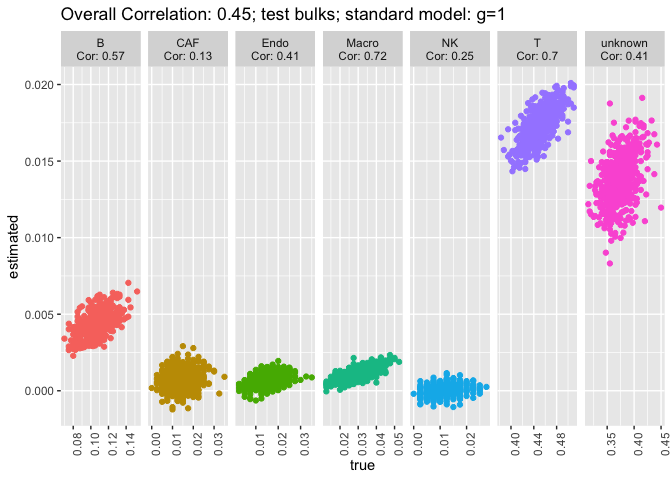

```r
standard.model <- rep(1, n.features)
names(standard.model) <- selected.feature
ggplot_true_vs_esti(
  DTD.model = standard.model,
  X.matrix = X.matrix,
  test.data = test.data,
  estimate.c.type = "direct",
  title = " test bulks; standard model: g=1"
)
```

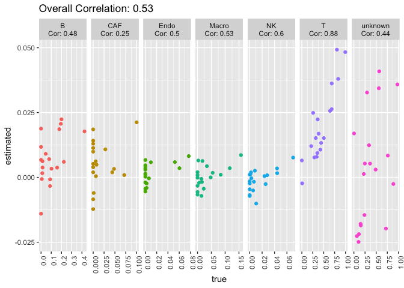

```r
bulk.list <- list(
  "mixtures" = normalize_to_count(bulk.exprs[selected.feature, ]),
  "quantities" = t(bulk.pheno[, colnames(X.matrix)])
)
ggplot_true_vs_esti(
  DTD.model = standard.model,
  X.matrix = X.matrix,
  test.data = bulk.list,
  estimate.c.type = "direct"
)
```

## Train a deconvolution model

Using the `train_deconvolution_model` function a deconvolution model is adapted to the tissue scenario. In that function several hyperparameters can be set via `...`. They will be passed to `DTD_cv_lambda` and `descent_generalized_fista`.  
The `train_deconvolution_model` function finds the best fitting lambda via cross validation, and then builds a model on the complete training data. After that, it automatically calls plot functions with default parameter, and stores the pictures in the `pic` entry of the model list. Notice, if a vector of $\lambda$ is passed to the algorithm via the ‘lambda.seq’ parameter, the algorithm will use this vector for cross validation. If ‘lambda.seq’ is not set, the algorithm internally generates a vector of $\lambda$ based on the dimension of the `training.data`.

```r
start.tweak <- rep(1, n.features)
names(start.tweak) <- selected.feature
lambda.sequence <- 2^seq(0, -50, length.out = 20)
model <- train_deconvolution_model(
  tweak = start.tweak,
  X.matrix = X.matrix,
  train.data.list = training.data,
  test.data.list = test.data,
  estimate.c.type = "direct",
  maxit = 50,
  lambda.seq = lambda.sequence,
  verbose = FALSE,
  cv.verbose = TRUE,
  warm.start = TRUE
)
```

```
##
## doing lambda:  1 , completed  0  of  20 ,  0 %
## doing l.fold: 1  2   3   4   5
## doing lambda:  0.1613674 , completed  1  of  20 ,  5 %
## doing l.fold: 1  2   3   4   5
## doing lambda:  0.02603944 , completed  2  of  20 ,  10 %
## doing l.fold: 1  2   3   4   5
## doing lambda:  0.004201916 , completed  3  of  20 ,  15 %
## doing l.fold: 1  2   3   4   5
## doing lambda:  0.0006780523 , completed  4  of  20 ,  20 %
## doing l.fold: 1  2   3   4   5
## doing lambda:  0.0001094155 , completed  5  of  20 ,  25 %
## doing l.fold: 1  2   3   4   5
## doing lambda:  1.76561e-05 , completed  6  of  20 ,  30 %
## doing l.fold: 1  2   3   4   5
## doing lambda:  2.849119e-06 , completed  7  of  20 ,  35 %
## doing l.fold: 1  2   3   4   5
## doing lambda:  4.597549e-07 , completed  8  of  20 ,  40 %
## doing l.fold: 1  2   3   4   5
## doing lambda:  7.418946e-08 , completed  9  of  20 ,  45 %
## doing l.fold: 1  2   3   4   5
## doing lambda:  1.197176e-08 , completed  10  of  20 ,  50 %
## doing l.fold: 1  2   3   4   5
## doing lambda:  1.931852e-09 , completed  11  of  20 ,  55 %
## doing l.fold: 1  2   3   4   5
## doing lambda:  3.117379e-10 , completed  12  of  20 ,  60 %
## doing l.fold: 1  2   3   4   5
## doing lambda:  5.030433e-11 , completed  13  of  20 ,  65 %
## doing l.fold: 1  2   3   4   5
## doing lambda:  8.11748e-12 , completed  14  of  20 ,  70 %
## doing l.fold: 1  2   3   4   5
## doing lambda:  1.309897e-12 , completed  15  of  20 ,  75 %
## doing l.fold: 1  2   3   4   5
## doing lambda:  2.113746e-13 , completed  16  of  20 ,  80 %
## doing l.fold: 1  2   3   4   5
## doing lambda:  3.410897e-14 , completed  17  of  20 ,  85 %
## doing l.fold: 1  2   3   4   5
## doing lambda:  5.504076e-15 , completed  18  of  20 ,  90 %
## doing l.fold: 1  2   3   4   5
## doing lambda:  8.881784e-16 , completed  19  of  20 ,  95 %
## doing l.fold: 1  2   3   4   5
## cross validation completed, starting to build model on complete data, with  best lambda
```

## Assess the trained deconvolution model

In this section, I show visualizations of the training process of the model. In the first plot the cross validation is visualized. The selected $\lambda$ is indicated via the red dot. Notice, in the `ggplot_cv` function the parameter `upper.x.axis.info` can be set to either `"non-zero"` or `"geometric-mean"`. If set to `"geometric-mean"`, the upper x axis shows the geometric mean of the weight vector $g$ per $\lambda$, averaged over all folds.

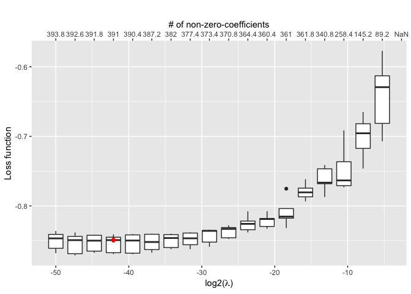

```r
print(model$pics$cv)
```

In the `convergence` entry, the visualization of the loss L against the iteration of the gradient descent is shown. If the `test.data` is provided to the `ggplot_convergence` function, and all intermediate $g$ vectors are stored in the model, the test convergence is visualized as well:

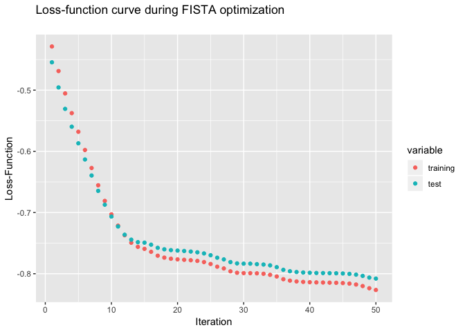

```r
print(model$pics$convergence)
```

In the `path` entry, the path of each $g_i$ is visualized over all iterations. Notice, that by default, the legend is not plotted. In the `ggplot_gpath` function the parameter `show.legend` can be set `TRUE`, then a legend is plotted as well.

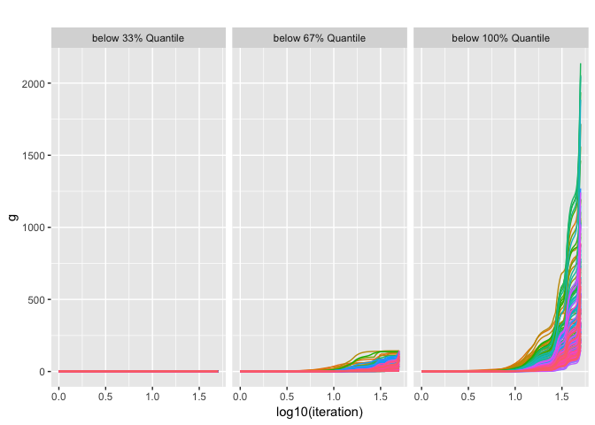

```r
print(model$pics$path)
```

The distribution of the $g$ vector is visualized as a histogram in the `histogram` entry. Basically, if gene $i$ has a deconvolution potential, its entry $g_i$ will potentially be high, even though the absolute size of $g$ can not be interpreted directly:

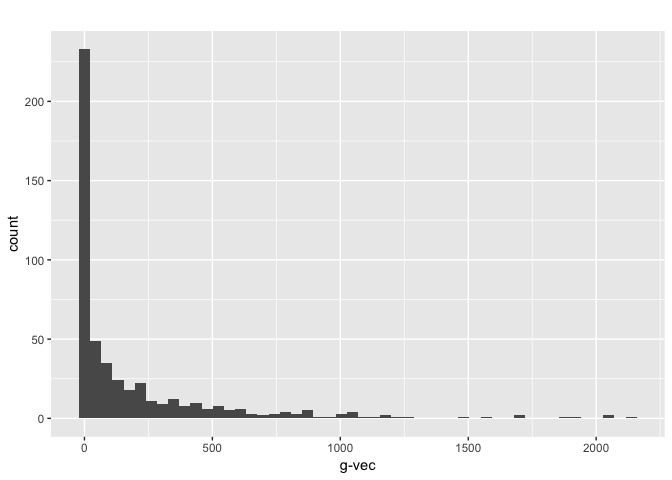

```r
print(model$pics$histogram)
```

The effect of the $g$-vector on deconvolution can be visualized when plotting the reference matrix $X$, multiplied with $g$, as a heatmap. Plot it via the `Xheatmap` entry, or the `ggplot_heatmap` function. Rows and columns are clustered hierarchically. The heatmap becomes more informative if only a subset of features is included. A subset can be selected via the `feature.subset` parameter:

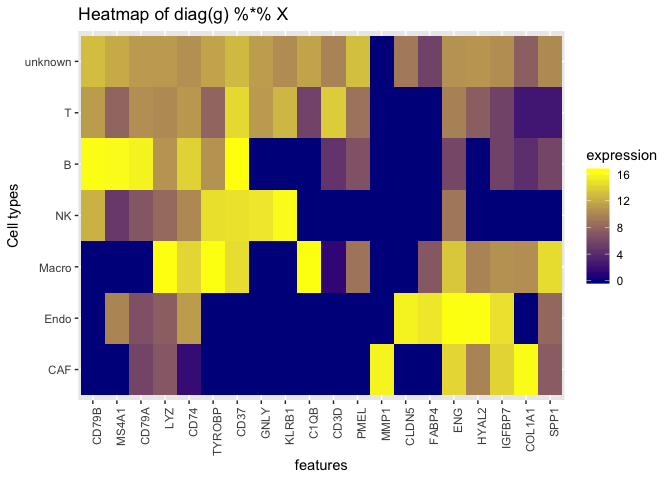

```r
#print(model$pics$Xheatmap)
ggplot_heatmap(
  DTD.model = model,
  X.matrix = X.matrix,
  test.data = test.data,
  estimate.c.type = "direct",
  title = "Heatmap of diag(g) %*% X",
  feature.subset = 20
)
```

Last but not least, the ‘true C versus estimated $\widehat{C}(g)$’ plot (as for the untrained model) is plotted:

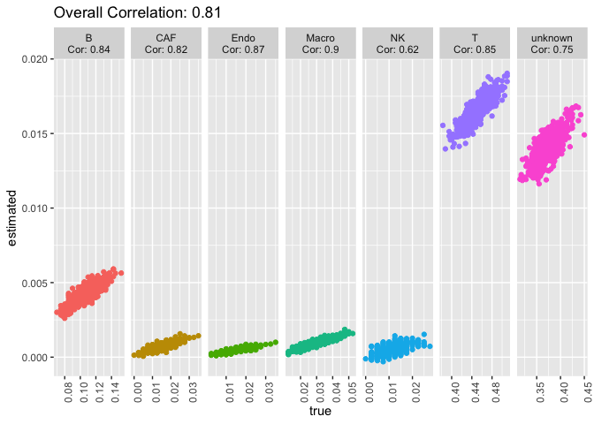

```r
print(model$pics$true_vs_esti)
```

## Deconvolute bulk profiles

A **DTD** model can be applied to estimate cellular compositions via the `estimate_c` or `estimate_nn_c` (for estimate non negative c) functions. As input, both take a reference matrix $X$, the data to be deconvoluted (notice, a expression matrix, not a list), and the **DTD** model. The output is a estimated cellular composition matrix $\widehat{C}(g)$. Visualizing ‘true C versus estimated $\widehat{C}(g)$’ can be done with the `ggplot_true_vs_esti` function. Pass the `bulk.list` to the `test.data` parameter.

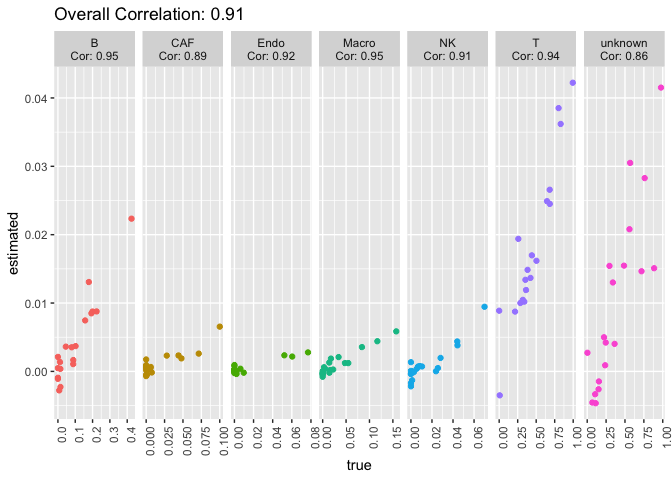

```r
# estimate cellular compositions of bulk profiles:
estimated.c.bulk <- estimate_c(
  X.matrix = X.matrix,
  new.data = bulk.list$mixtures,
  DTD.model = model
)
# visualize true bulk C versus estimated bulk C:
ggplot_true_vs_esti(
  DTD.model = model,
  X.matrix = X.matrix,
  test.data = bulk.list,
  estimate.c.type = "direct"
)
```

# References

Görtler, Franziska, Stefan Solbrig, Tilo Wettig, Peter J. Oefner, Rainer Spang, and Michael Altenbuchinger. 2018. *Research in Computational Molecular Biology: 22nd Annual International Conference, Recomb 2018, Paris, France, April 21-24, 2018, Proceedings (Lecture Notes in Computer Science)*. Springer.

Tirosh, I., B. Izar, S. M. Prakadan, M. H. Wadsworth, D. Treacy, J. J. Trombetta, A. Rotem, et al. 2016. “Dissecting the Multicellular Ecosystem of Metastatic Melanoma by Single-Cell RNA-Seq.” *Science* 352 (6282). American Association for the Advancement of Science (AAAS): 189–96. doi:10.1126/science.aad0501.